# Measuring local biodiversity with Diversity Measures at Distance

Eric Marcon , Florence Puech  
December 16, 2025

# Introduction

Biodiversity and its conservation are a key challenge of contemporary times (IPBES 2019; Roy et al. 2023), and evaluating biodiversity is the first step for any analysis or policy development. Therefore, measuring biodiversity precisely and making its results intelligible is essential for biodiversity analysis and the subsequent estimation of the costs associated with biodiversity erosion (Turbelin et al. 2023). Biodiversity covers all forms of living organisms; thus, many different approaches and definitions have been proposed for its evaluation. A certain number of biological diversity measures are very well-known and largely used (e.g., the Shannon index or the Simpson index) while others remain quite confidential (Krebs 1999).[^1] While previous research has emphasized that diversity measures should be rigorously developed because each indicator responds to a particular definition of diversity, the scale at which diversity has to be evaluated is less discussed. Diversity level has generally been estimated within a predefined zone; for example, plots in forests (Broadbent et al. 2008) or regions such as the French Small Agricultural Regions (Pythagore et al. 2017; Cocco, Kervinio, and Mouysset 2023). To the best of our knowledge, no approach has been developed to simultaneously assess local diversity (*i*) for any distance of an environment analyzed and (*ii*) for any chosen definition of diversity. This study fills the gap by providing a new class of indices called Diversity Measures at Distance (DMD), which are based on the Hill numbers (Hill 1973) and make it possible to interpret diversity results regardless of the entropy measure used. The **divent** R package (Marcon and Puech 2025) offers simple DMD computation and explicit mapping of local diversity.

We expect our proposed DMD to be of considerable interest to researchers in many fields. For example, consider a case of a disease contagion that affects biodiversity. If we suppose that biotic factors are greater at small scales (Cohen et al. 2016) and if we suspect that interactions between species occur at very small distances, biodiversity must be precisely measured at a very small scale and at any point of the territory. Diversity evaluations at a large scale are far less pertinent in such cases than those made in a close environment. The reason is that such contagions affect immediate neighbors, not those located at large distances. Measuring diversity at too large a scale is insufficiently informative for identifying infested areas. In that sense, DMD enables a more comprehensive understanding of the underlying interactions between the species analyzed. Such local diversity evaluations are essential and offer a considerable opportunity to limit the economic costs associated with contagious diseases in terms of monitoring, mitigation, and treatment.

The remainder of this paper is organized as follows. Section 2 provides a review of contemporary diversity indices. As we show, any index has a specific meaning in gauging biodiversity; therefore, the use of a given index must be constructed with care and motivates our analysis to examine various indicators. This section also introduces Hill numbers (Hill 1973) that are at the basis of the DMD. We explain why Hill numbers are essential to correctly quantify diversity. We then introduce the DMD in Section 3, presenting the statistical framework and associated utility in measuring diversity. Section 4 presents an empirical application for evaluating biodiversity with the DMD that is focused on the diversity of tree species located in the *Parc des Buttes Chaumont* in Paris. Our results demonstrate that species biodiversity varies greatly inside the park, and this finding remains robust regardless of the local scale used or the definition of biodiversity applied. The results confirm that a park-wide estimation of diversity obviously masks local disparities of diversity that DMD on the contrary perfectly grasp. In Section 5, we conclude by highlighting the utility of the DMD for environmental economics application and discuss future research in the field.

# Diversity indices: a review of the most common diversity indices

Numerous diversity measures coexist in previous research (Baumgärtner 2006). Some are well-known and applied in many applications and others remain quite confidential. The richness, the Shannon index, and the Simpson index are among the best known and most widely used to evaluate biodiversity. In this section, we present and discuss these three indices. For clarity, we consider trees as a taxonomic group in the following illustrative examples.[^2] Each tree is associated with a unique species and the biodiversity level is based on an indicator that quantifies tree species diversity.

## Richness

Richness is the most simple and intuitive index to present. If we focus on species, species richness is defined as the total number of different species located in the area under study (McIntosh 1967). Practically, a higher number of species indicates higher diversity. According to this definition, the number of individuals per species (i.e., *abundance*) is not considered as the diversity measurement captured by species richness only concerns the number of different species located on the area under study. As a result, the diversity of two forests with the same number of species will be exactly the same, regardless of the number of trees located in each forest. In practice, measurement difficulty is related to territories for which an exhaustive count of all individuals is challenging (e.g., for tropical forest), wherein rare species may not be observed and richness is underestimated. More sophisticated techniques based on nonparametric methods may be useful in such cases, and developments have been proposed following Chao (1984) or Burnham and Overton (1979).

## Shannon index

The Shannon index (Shannon 1948) integrates the abundance of species to measure diversity. To understand the Shannon index intuitively, we will use the following example. Consider a forest where each tree is only characterized by its species. In more technical terms, consider an experiment with $S$ possible outcomes denoted $\{r_1, r_2,... r_s,..., r_S\}$. In our case, the outcomes correspond to the species of an observed tree. The *rarity* of species is defined as ${1}/{p_s}$, where $p_s$ is the probability of obtaining the outcomes $r_s$ among the *S* experimental outcomes. The minimum value of rarity is 1, which is obtained if only one species is present. The maximum value is reached when species *s* is rare, in which case, $p_s$ is extremely small and rarity tends toward infinity. The logarithm of rarity is the Shannon information function denoted as $I(p_s)$, which decreases when $p_s$ increases. If $p_s$ tends toward zero, then the information tends toward infinity and it takes a value of 0 if $p_s$ equals to 1. As Shannon argued, the information function can be understood as a quantity of surprise. If a species is rare (e.g., $p_s$ is small), the quantity of information for that outcome is high, and as a consequence, $I(p_s)$ is high. In contrast, if some species are abundant, the quantity of surprise associated with its outcome is low, as is the information function. The Shannon entropy index is defined as the average information given by all possible outcomes of the experience as follows:
$$\begin{equation}
\sum_s{p_s \ln\frac{1}{p_s}}
\tag{1}
\end{equation}$$

The Shannon index determines the level of the average information generated by a random draw of an individual. Shannon called this entropy by analogy with statistical physics, referencing the characterization of the complexity of gas particles by Boltzmann (1877, translated by Sharp and Matschinsky 2015). However, no simple, intuitive interpretation of the numerical value of Shannon’s entropy has been produced. We will return to this point in the discussion.

## Simpson index

The index can be understood as the probability of drawing two entities that belong to two different species. If we retain the same notations as in the Shannon index equation, the Simpson index can be defined as follows:

$$\begin{equation}
1-\sum_s{{p_s}^2}
\tag{2}
\end{equation}$$

The minimum value of the Simpson index is 0, which occurs when a species has a probability of being drawn of 1. The maximum value is 1, which occurs with a large number of species, which makes $p_s$ close to 0. Therefore, any diversity value can be obtained between these two extreme cases.

## Unification: Generalized entropy

Classical biodiversity indices can be unified using information theory. Richness and Simpon’s indices can be understood as variations of the Shannon index wherein the information function is respectively $(1 - p_s) / p_s$ and $1 - p_s$.

An elegant unification (Marcon et al. 2014) is possible using the generalized entropy proposed by Tsallis (1994). The deformed logarithm of order *q*, where *q* is a parameter, is a function that deforms the natural logarithm by changing its curvature but remains an increasing function and respects $ln_q{1}=0$. The deformed logarithm of order *q* is defined as follows:

$$\begin{equation}
\begin{cases}
\ln_q{x} &= \frac{x^{1-q} - 1}{1 - q}, q \ne 1 \\
\ln_1{x} &= \ln x
\end{cases}
\tag{3}
\end{equation}$$

The three common diversity indicators presented above constitute particular cases of the generalized Tsallis entropy. The definition of the Shannon index (eq. (1)) can be generalized as follows:

$$\begin{equation}
^{q}H = \sum_s{p_s \ln_q\frac{1}{p_s}}
\tag{4}
\end{equation}$$

Special values of *q* define *orders* of entropy as follows:

- If *q=0*, equation (4) reduces to $\sum_s{p_s(\frac{1}{p_s}-1)}$, which equals the number of species minus 1 and is denoted as $^{0}H$.
- If *q=1*, the generalized entropy is simply Shannon’s entropy, denoted as $^{1}H$.
- If *q=2*, we obtain a value $1-\sum_s{{p_s}^2}$ in equation (4), which is the Simpson index, denoted as $^{2}H$.

These three *q* values are the most used, but are not exclusive (Baumgärtner 2007). Equation (4) defines the entropy of order *q* as the average information from individual observations, where the information is a deformed logarithm of species rarity. Parameter *q* can be understood as the instrument for assigning more or less importance to rare species. Small values emphasize them, where a species with a single individual counts for 1 in richness (*q=0*), not less than a species that encompasses all individuals but 1: in this example richness is 2.

Increasing *q* lowers the rare species count. The Simpson’s entropy of our example is close to 0, as if the rare species did not exist.[^3]

## Hill numbers

The Hill numbers of order $q$ (Hill 1973) are the number of equiprobable species that obtains the same entropy as the observed distribution. Hill numbers can be computed as the deformed exponential of entropy as follows:

$$\begin{equation}
^{q}D = e_q^{^{q}H}
\tag{5}
\end{equation}$$

where the deformed exponential is the reciprocal function of the following deformed logarithm:

$$\begin{equation}
\begin{cases}
e_q^{x} &= (x(1 - q) + 1)^{\frac{1}{(1 - q)}}, q \ne 1 \\
e_1^{x} &= e^x
\end{cases}
\tag{6}
\end{equation}$$

Hill numbers enable an intuitive understanding of entropy. We present the following example to explain this more clearly. Imagine that 4 is the estimated Hill number of order 1 that measures the diversity of tree species in a park. This means that four tree species in the park with the same probability of apparition (each one equal to $1/4$) would constitute the park’s Shannon’s entropy. This entropy is $ln(4) \approx 1.4$; a value that cannot be easily interpreted. Hill numbers reduce the complexity of diversity indices to a single value for each order, which is also called the *effective number of species*.

## Discussion

A series of remarks can be drawn from this short presentation of the most traditional diversity measurements.

**Diversity can be evaluated in multiple ways.** Different concepts of diversity can be explored, resulting in different measurements. As a consequence, using one given index should thus be carefully considered, e.g., see Dickman (1968), Peet (1974) or more recently, Morris et al. (2014), Nagendra (2002). Diversity indices should always be motivated by the research question under study, as is the case for any quantitative indices (Marcon and Puech 2017). Here, we only consider species-neutral measures of diversity, ignoring species’ identity and considering them equally different, in contrast to phylogenetic (Vellend et al. 2010) or functional (Leinster and Cobbold 2012) diversity that consider dissimilarity but are beyond our scope. Therefore, the choice of one specific diversity index is only driven by the importance assigned to rare species. Species richness is a central measure for conservation purposes while Simpson’s diversity is a better tool for assessing community functioning, e.g., carbon storage, driven by a dominant species (Liang et al. 2016).

While the three classical indices are the most used, it is **difficult to interpret entropy measures** (Jost 2006) beyond the special orders 0 and 2. In contrast, the Hill numbers make diversity immediately intelligible as the dimension is the number of species, which can be compared between different orders of diversity wherein a diversity profile plots diversity with respect to its order (Tothmeresz 1995).[^4] Hill numbers enable a comparison of two entities’ diversity, e.g., two parks, at all orders.

Jost (2006) argued that only the Hill numbers should be called *diversity*, while classical indices should be called *entropy*. Both are more than indices; they are *measures* of diversity (Jost 2009). The Hill numbers refer to the number of species, and entropy concerns the amount of information.

# Introducing Diversity Measures at Distance

A unified framework for local diversity measurement based on an entropy framework has not yet been conceived in the literature. Our proposed DMD fills this gap by presenting a continuous framework for evaluating biodiversity in three steps.

**Step 1: The choice of the distance.** Diversity is measured around each entity analyzed at distance *r*, which can take any value (e.g., 5 meters, 10 meters, 50 meters etc.) required by the underlying model or theoretical assumptions of the research question. For example, if we are examining a contagious disease that spreads between trees and we suspect that the level of biodiversity matters, this should be calculated at a very small radii *r* around each tree.

**Step 2: Choosing the order of diversity.** This choice determines the value of $q$ for the Hill number. One decision rule is the importance assigned to rare or abundant species. If the researcher wants to treat all species in the same way, *q=1* is a reasonable choice in ecology (e.g., see the discussion in Roswell, Dushoff, and Winfree (2021) on this point). More generally, this step depends on a certain number of “value judgments” (Baumgärtner 2006, 2007) that should be clearly motivated for each study.

**Step 3: Visualizing the results.** Mapping the calculated Hill numbers is highly convenient for illustrating all results. Therefore, we proceed as follows. First, we calculate the entropy at order *q* around each geolocalized entity for the chosen distance *r*. We then calculate the estimated Hill numbers around each entity by taking the exponential of entropy values. We then apply a spatial smoothing of values to plot them across the area for visualization, using the *Smooth.ppp()* function of the R package Spatstat, (Baddeley and Turner 2005). We employ Gaussian kernel smoothing with the bandwidth as defined by Scott (1992). We recommend the use of contour lines that identify similar values to Hill numbers’ estimates. We then use the new R package (divent) to compute DMD (Marcon and Puech 2025). This R package facilitates researchers’ use of R code to calculate DMD and visualize their results.

# Empirical application on trees in the *Parc des Buttes Chaumont* (Paris)

As proof of concept, we apply DMD to evaluate the biodiversity of the *Parc des Buttes Chaumont*, a Parisian park located in the 19<sup>th</sup> arrondissement that was established in 1867 and is an considerably large park area in the northeast of Paris of an approximate 25-hectare area.[^5]

We only base biodiversity evaluation in *Parc des Buttes Chaumont* analyzing trees. Among all taxa, trees seem to be particularly noteworthy for park users (Muratet et al. 2015). We obtain the geolocalization of trees and their characteristics from *Paris open data*, which is available at: https://opendata.paris.fr.[^6] This database contains more 200,000 trees inventoried in the majority of spaces managed by the city of Paris. All results and maps of local biodiversity levels are provided in the appendix in addition to data and R code for reproducible research.

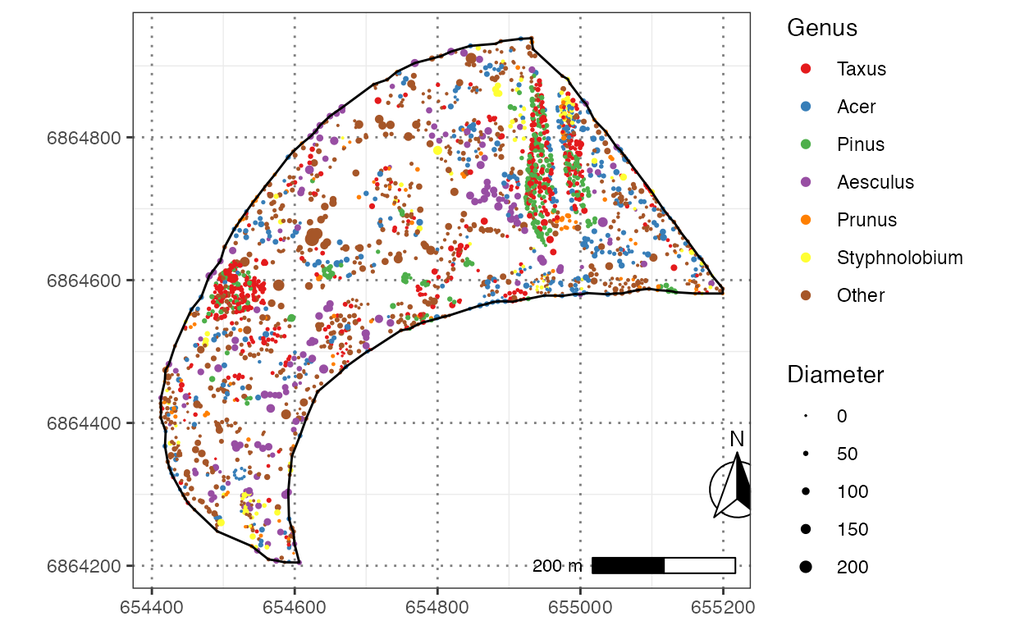

## Overview of the area

The geolocalized positions of trees in the *Parc des Buttes Chaumont* is provided in addition to some characteristics, notably their genus, species, and circumference. We retain the circumference to calculate trees’ diameter, which we use as a proxy of their trunk area cut 1.3 meters above ground (“at breast height” in forestry vocabulary). The spatial distribution of trees in February 2025 is presented in Figure 1.

(ref:Distribution) **Spatial distribution of trees in the *Parc des Buttes Chaumont*.**  
Note: Distribution is obtained from Paris Open Data in February 2025. The most abundant genera are presented in decreasing order. Coordinates on both axes are in meters (Lambert 93 projection) and diameters are in centimeters. We magnified the visualization of individual diameters twice for improved readability.

A total of 2356 trees are distributed across the park, with the exception of the lake at the center of the park that surrounds an island, grassy areas (notably, south of the lake), paths, and the railway, which is easily identified by the straight line at the eastern part of the park. The most frequent trees are of the genera *Taxus* (yews), *Acer* (maples), and *Pinus* (pines), representing more than the half of the trees in the park. Yews and pines are highly overrepresented in some portions of the park, as illustrated in Figure 1. If we consider the species of trees (and not only genus), only four -the common yew (*Taxus baccata*), the black pine (*Pinus nigra*), the sycamore maple (*Acer pseudoplatanus*) and the horse chestnut (*Aesculus hippocastanum*)- represent around the half of the total number of tree species in the *Parc des Buttes Chaumont*.

## Measuring diversity at the park level

In the first step, we compute the three common entropy indices park-wide, emphasizing two main results.

- Richness is 149, indicating that 149 species are inventoried across the park. This level of richness is quite high because many trees were intentionally planted; therefore, the diversity level in the park is greater than that observed in European forests (Slik et al. 2015).
- Over the entire *Parc des Buttes Chaumont*, the Shannon index is estimated to be 3.42 and the Simpson index is 0.92. Galle et al. (2021) noted that ecological studies have predominantly elicited Shannon index values between 1.5 and 3.5, but these values are difficult to interpret.

In the second step, we estimate the Hill numbers for the entire park as a unique site to determine the number of equiprobable outcomes that have the same entropy as the observed system (Hill 1973). Figure 2 presents the results, which is called a diversity profile (Tothmeresz 1995). All orders of diversity are represented because they have the same unit value; the number of species. The value of the classical orders of diversity are presented in the plot. Shannon’s diversity ($q=1$) equals the exponential of Shannon’s entropy of 30. This diversity value means that 30 species with the same probability of occurrence have the same diversity of order 1 as the *Parc des Buttes Chaumont*.

Simpson’s diversity is 13. Diversity is a decreasing function of its order as rare species are increasingly neglected when $q$ rises and less equiprobable species are needed to provide the observed level of diversity. If all species were actually equiprobable, then the diversity profile would be flat and diversity would equal richness, regardless of the order considered.

This result is noteworthy but it certainly masks some fluctuations in diversity that may appear inside the park, at a thinner level than park-wide. The local diversity analysis presented in the next subsection will provide an answer.

(ref:ProfileHill) **Profile of the Hill numbers on the entire *Parc des Buttes Chaumont* in 2025.**  
Note: Diversity is plotted based on order wherein richness corresponds to order 0, Shannon’s index to order 1, and Simpson’s index to order 2. Calculations are based on Paris Open Data in February 2025.

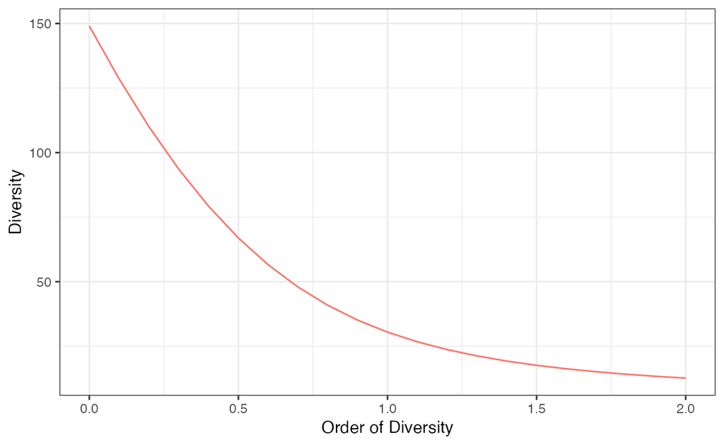

## Measuring local diversity with DMD

### Local biodiversity maps

As a proof of concept, we evaluate the local diversity of trees in *Parc des Buttes Chaumont* based on richness, Shannon, and Simpson indices for distances of 5 meters and 25 meters.

In what follows, we only consider diversity using Hill numbers to enable interpretation of the diversity results for any entropy measure or local distance. As expected, the results enable the continuous measurement of local biodiversity levels across the park. All maps in Figure 3 are interpretable in terms of effective numbers of species and the Hill numbers are directly observed on scale or contour lines that offer an easy illustration of local diversity levels. The gradient of colors helps to identify areas with high local biodiversity (warm colors) and those with low local biodiversity (cold colors).

(ref:DiversityMap) **Local tree diversity (Hill numbers) in the *Parc des Buttes Chaumont*.**  
Note: Orders of diversity are 0 (first row), 1 (second row), and 2 (third row). Distances are 5 meters (first column) and 25 meters (second column). Distribution is based on Paris Open Data in February 2025. Coordinates on both axes are in meters (Lambert 93 projection).

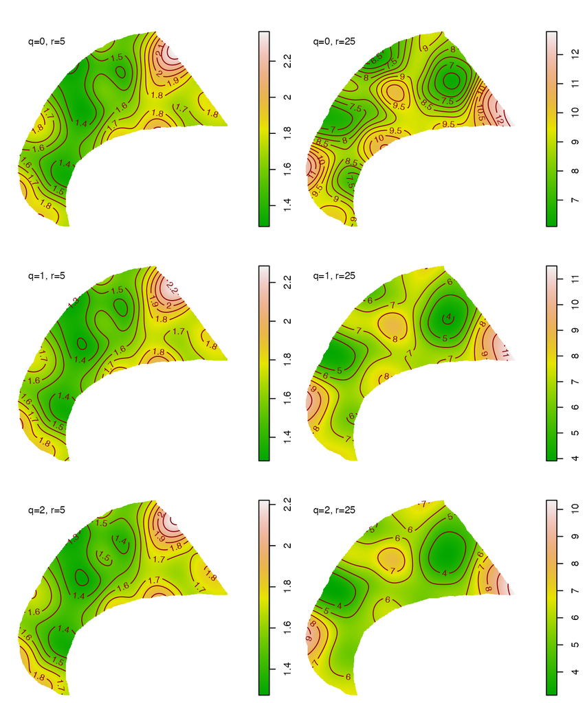

### Key results on local biodiversity provided by DMD

- *Result 1: Levels of biodiversity observed across the park vary greatly.*

This result is obtained regardless of the map considered; therefore, we confirm that diversity estimations of *Parc des Buttes Chaumont* at the scale of the park obviously mask local disparities in diversity. Regardless of the measure of diversity or distance used, we can easily and clearly identify some areas characterized with high biodiversity values and others with medium or low biodiversity. This confirms that a park-wide biodiversity estimation may be too crude to accurately characterize the observed biodiversity.

# Implications for environmental economics

## Main improvements

Our proposed DMD approach responds to different objectives.

**First, our methodology enables biodiversity measurement as a multiscale phenomenon.** As interactions within the living world can be observed from very microscopic to broad levels, indicators at any geographical scale can be easily integrated. This framework is possible by adopting an internal perspective that is from every entity composing the taxonomic group(s) under study and not from an external perspective. Employing the distance surrounding the entities that compose the taxonomic group(s) seems to be an effective research approach for accurately determining the effect of their environment. Some studies have previously noted the importance of precisely considering the scale of observation for understanding the effects of different taxonomic groups on the environment. For example, Brunbjerg et al. (2018) focused on this point for birds, bats, bees, and hoverflies, and Marcon and Puech (2023) about contagious diseases in trees.

A notable feature of the proposed DMD measurement is that it should be less exposed to the Modifiable Areal Unit Problem (MAUP) (Openshaw and Taylor 1979; Openshaw 1984), which results from zoning a territory for data that were initially nonaggregated. As a consequence, zoning estimates are affected by the position and size of the zones under study. Zoning construction and the level of spatial resolution could be more or less sophisticated (Féret and Asner 2014; Mouchet et al. 2017; Bareille, Boussard, and Thenail 2020). For example, Bennie, Anderson, and Wetherelt (2011) introduced a paired-sample version of the Simpson index based on the lag distance between two samples. This problem has been widely studied in many fields of research and an approach centered on the entities analyzed has been identified to circumvent the MAUP, e.g., Arbia (1989) in economics and Jelinski and Wu (1996) in ecology.

**Second, the methodology proposed in this article fully aligns with existing research that sought to assess space in a more precise manner when measuring biodiversity.** Our method complements studies that have integrated entities’ neighborhoods by adopting an approach that is not based on zoning but centered on the entities analyzed. Therefore, our method aligns with Wiegand et al. (2007), who used a spatial point process methodological framework, retaining the continuity of distances between geolocalized entities’ positions. The model, called Individual Species-Area Relationships (ISAR), subtly links the well-known theoretical framework of the Ripley’s $K$-function (Ripley 1976, 1977), combining distance-based measures and the notion of diversity. This entity-centered approach enables an analysis of entities’ local environments at all distances. Although this measure can be used for all distances, in their empirical example, the authors only chose a unique distance of 30 meters to map diversity values for Barro Colorado Island (Panama) and Sinharaja (Sri Lanka) sites. Mapping is a useful technique for determining locally observed diversity for a specific distance motivated by a precise research question.[^7]

In the same vein, Marcon and Puech (2023) emphasized the usefulness of mapping spatial structures in continuous space with a measure derived from the Ripley’s $K$ function that is applicable in a heterogeneous space (not a homogeneous one as for the Ripley’s $K$ function). This measure, called the *M* function, is applied to a case of a contagious disease that affects maple trees in a Parisian park. This function is not linked to the concept of diversity in the article but that of spatial concentration. While the average environment can be described for each distance, a focus on specific distances reveals interactions between the entities analyzed and characterizes spatial structures of concentration or dispersion.

The continuous approach for assessing diversity proposed in this study is not based on the ISAR method or graph theory, e.g., Rajala and Illian (2012), but on entropy measures centered on the entities analyzed. Consequently, our approach also aligns with research examining the spatialization of entropy indices. For example, Shimatani (2001) proposed *distance-dependent Simpson indices* to examine the level of diversity around entities for a distance *r*; however, no local mapping of values was proposed, and an interpretation of diversity values was not presented. The spatialization of the Shannon index was also investigated since Batty (1974), and Altieri, Cocchi, and Roli (2021) provide an overview of this literature. Some contributions have been proposed considering zoning territory (Boroushaki 2017) and individual-centered analysis. For example, Reardon and O’Sullivan (2004) defined local estimation of entropy around an entity for socioeconomic purposes.

**Finally, our methodology offers the possibility to accurately understand the meaning of the local diversity results observed.** As we previously emphasized, no intuitive interpretation of the Shannon or Simpson entropy is available. Our approach, based on the Hill numbers, fills that gap for the richness, Shannon and Simpson biodiversity indices. The interpretation of the biodiversity results is crucial. For example, biodiversity measurements are essential for decision makers, as indicators provide decision-making tools for public policy development (European Parliament et al. 2020; Bureau, Bureau, and Schubert 2020). Accurately measuring biodiversity and making its results intelligible is essential for the biodiversity analysis to estimate the costs associated with biodiversity erosion and restoration (Turbelin et al. 2023). Moreover, local diversity can be obtained via the DMD with a thin representation of the diversity levels. Mapping local diversity results is a way to reach this objective. In summary, proposing the unified DMD analysis framework that enables local representation of diversity at distance, regardless of the entropy measure chosen, with results that can be easily interpreted. We present the methodology adopted for that purpose in the next section.

## DMD as a first-class instrument for measuring biodiversity

First, we demonstrate that **continuous diversity measures enable precise evaluation of local diversity.** The high variability of the local measurement in our empirical example verifies the importance of using a continuous approach when measuring biodiversity. An evaluation of park-level biodiversity can be informative but is insufficient for addressing processes that can occur at smaller scales. The economic stakes associated with biodiversity are enormous and the importance of developing statistical tools for accurate measurement has been intensely examined (Cognie and Péron 2020; Strange et al. 2024). The analysis developed in this study contributes to improving biodiversity evaluation. Moreover, geolocalized environmental data are becoming increasingly available. Consequently, if geolocalized data are available, we recommend retaining a continuous approach toward space. Treating space as a collection of spatial units faces many challenges that have been summarized by the MAUP. The key point is that aggregating spatial data erases particularities that are precisely what we seek to reveal. As we emphasize, biodiversity measurement is a first step in the overall analysis and estimates should be precise and unbiased. DMD offers this possibility.

Second, **the proposed *divent* R package enables the calculation of the DMD.** The continuous calculation and mapping of diversity for the *Parc des Buttes Chaumont* only takes a few dozen seconds on a personal computer, depending on its performance. This computation time is considerably longer than park-wide, but remains tractable for quite large datasets.

Finally, as DMD is powerful for measuring biodiversity, **the definition of the local diversity should be carefully motivated.** The distance at which the evaluation is conducted and the definition of the biodiversity chosen really matter. As a consequence, a precise motivation for the order of diversity used and the distance chosen is highly recommended for any analysis. Therefore, economic theory should be mobilized and developed to address this concern in future research endeavors. This warning is exactly the same when using a distance-based method to measure spatial concentration (Marcon and Puech 2017).

## Potential applications

This study opens the way to numerous applications of DMD in environmental economics. Our methodology can be easily integrated and developed in economic models that include environmental variables. The advantage is that local biodiversity can be evaluated within the framework of a continuous space, regardless of the geographic scale chosen. For example, consider hedonic price models for properties. The local biodiversity level may be one of the characteristics that explains properties’ price. Indeed, studies have demonstrated that properties’ environmental characteristics are an important consideration. For example, a lake or ocean view and quality have a positive effect on property price (Brookshire et al. 1982; Sirmans, Macpherson, and Zietz 2005). This is also applicable to the presence of trees in cities (see Sander, Polasky, and Haight 2010 for a review). The significance of local biodiversity can be evaluated using DMD.

Another research method could be integrating DMD into recreational ecosystem services models. A more accurate treatment of space in the biodiversity measurement should enrich the actual evaluation of advantages provided by nature that has constituted a real and significant challenge for economists (IPBES 2019; Roy et al. 2023). For example, evaluating biodiversity at the forest or park scale requires an external perspective. The DMD framework offers a complementary approach to existing methods by evaluating diversity at the local rather than global level. As Reardon and O’Sullivan (2004), Shimatani (2001) or Wiegand et al. (2007), DMD applies biodiversity measurement from an internal perspective around any entity analyzed (e.g., trees) within any distance. This entity-centered approach introduces a new technique for investigating biodiversity. We present the following illustrative case for clarity. Consider a walker who strolls around an urban park or a forest. DMD enables the estimation of biodiversity perceived by this walker along the path. Biodiversity can be evaluated at a distance of 10–20 meters; for example, on the path and along the path if the view is unobstructed or lesser. An economic analysis may then be proposed, based on the local biodiversity estimates perceived from the chosen path. Such results can contribute to evaluating local recreational ecosystem services for walkers along the paths in the park. The interest of combining highly detailed diversity estimation and mapping has been previously demonstrated for evaluating ecosystem services (e.g., Hauck et al. (2013); Tardieu and Tuffery (2019); Suchocka et al. (2023)). The resulting map can provide easily understandable information on the diversity level in any point of the area examined. Therefore, this economic statistical development aligns with Peña, Casado-Arzuaga, and Onaindia (2015), who emphasized that *“[…] maps are valuable representations of real conditions and very powerful tools for communicating complex data and information”* for ecosystem services. Finally, it is logical that comparisons of results across time would be informative for policymakers to quantify local biodiversity variations more accurately; for instance, within a city or in particular areas. Local maps can be easily generated to identify areas with low or high biodiversity levels.

# Conclusion

This study introduces a new technique for measuring biodiversity at the local scale. The DMD is developed in a continuous-space framework for measuring local diversity using Hill numbers. The new R package *divent* supports the diversity measurement calculation.

This study proposes the first empirical application on trees in a Parisian park to demonstrate the advantages of DMD for measuring biodiversity. DMD offers a useful approach for researchers, particularly those engaged in environmental economics. This method provides a clear visualization of the biodiversity of the area studied. Furthermore, DMD offer a simple framework for providing precise diversity results that are comparable for any scale of observation, without any statistical bias.

DMD may be extended straightforwardly to phylogenetic and functional diversities, by incorporating distances between species (in ecology) or sectors of activity (in economics) based on a phylogeny or functional features in the definition of diversity.

# Appendix

R code is available at the following address: https://florencepuech.github.io/DMD/Appendix.pdf

# Acknowledgments

This research was conducted when Florence Puech was visiting Paris-Saclay Applied Economics (PSAE; INRAE-AgroParisTech). She gratefully acknowledges the financial support from INRAE and the Université Paris-Saclay MERR program. Eric Marcon was supported by labex CEBA, ANR-10-LABX-0025. Both authors are grateful for helpful comments received from seminar and conference participants, including the Spatial Econometrics and Statistics workshop (SEW), AFSE, FAERE, and seminars of the Department of Geography of the University of California in Santa Barbara and of Université Paris Nanterre.

# Conflict of interest

On behalf of all authors, the corresponding author states that there is no conflict of interest.

# CRediT authorship contribution statement

- **Eric Marcon:** Conceptualization, Data curation, Formal analysis, Funding acquisition, Investigation, Methodology, Project administration, Resources, Software, Supervision, Validation, Visualization, Writing.
- **Florence Puech:** Conceptualization, Data curation, Formal analysis, Funding acquisition, Investigation, Methodology, Project administration, Resources, Software, Supervision, Validation, Visualization, Writing.

# References

Altieri, Linda, Daniela Cocchi, and Giulia Roli. 2021. “Spatial Entropy for Biodiversity and Environmental Data: The R-Package SpatEntropy.” *Environmental Modelling & Software* 144: 105149.

Arbia, Giuseppe. 1989. *Spatial Data Configuration in Statistical Analysis of Regional Economic and Related Problems*. Dordrecht: Kluwer.

Baddeley, Adrian J., and R. Turner. 2005. “Spatstat: An R Package for Analyzing Spatial Point Patterns.” *Journal of Statistical Software* 12 (6): 1–42.

Bareille, Francois, Hugues Boussard, and Claudine Thenail. 2020. “Productive Ecosystem Services and Collective Management: Lessons from a Realistic Landscape Model.” *Ecological Economics* 169: 106482. https://doi.org/https://doi.org/10.1016/j.ecolecon.2019.106482.

Batty, Michael. 1974. “Spatial Entropy.” *Geographical Analysis* 6 (1): 1–31.

Baumgärtner, Stefan. 2006. *Measuring the Diversity of What? And for What Purpose? A Conceptual Comparison of Ecological and Economic Biodiversity Indices*. SSRN. https://doi.org/10.2139/ssrn.894782.

———. 2007. “Why the Measurement of Species Diversity Requires Prior Value Judgements.” In *Biodiversity Economics. Principles, Methods and Applications*, edited by Andreas Kontoleon, Unai Pascual, and Timothy Swanson, 293–310. Cambridge University Press.

Bennie, Jonathan, Karen Anderson, and Andrew Wetherelt. 2011. “Measuring Biodiversity Across Spatial Scales in a Raised Bog Using a Novel Paired-Sample Diversity Index.” *Journal of Ecology* 99 (2): 482–90. https://doi.org/https://doi.org/10.1111/j.1365-2745.2010.01762.x.

Boroushaki, Soheil. 2017. “Entropy-Based Weights for MultiCriteria Spatial Decision-Making.” *Yearbook of the Association of Pacific Coast Geographers* 79: 168–87.

Broadbent, Eben N., Gregory P. Asner, Marielos Peña-Claros, Michael Palace, and Marlene Soriano. 2008. “Spatial Partitioning of Biomass and Diversity in a Lowland Bolivian Forest: Linking Field and Remote Sensing Measurements.” *Forest Ecology and Management* 255 (7): 2602–16. https://doi.org/https://doi.org/10.1016/j.foreco.2008.01.044.

Brookshire, David S., Mark A. Thayer, William D. Schulze, and Ralph C. d’Arge. 1982. “Valuing Public Goods: A Comparison of Survey and Hedonic Approaches.” *The American Economic Review* 72 (1): 165–77.

Brunbjerg, Ane Kirstine, James D. Hale, Adam J. Bates, Robert E. Fowler, Emma J. Rosenfeld, and Jonathan P. Sadler. 2018. “Can Patterns of Urban Biodiversity Be Predicted Using Simple Measures of Green Infrastructure?” *Urban Forestry & Urban Greening* 32: 143–53. https://doi.org/https://doi.org/10.1016/j.ufug.2018.03.015.

Bureau, Dominique, Jean-Christophe Bureau, and Katheline Schubert. 2020. *Biodiversity in Danger: What Can Economics Do?* French Council of Economic Analysis, Les notes du conseil d’analyse économique, no 59, September 2020.

Burnham, K. P., and W. S. Overton. 1979. “Robust Estimation of Population Size When Capture Probabilities Vary Among Animals.” *Ecology* 60 (5): 927–36. https://doi.org/10.2307/1936861.

Chao, Anne. 1984. “Nonparametric Estimation of the Number of Classes in a Population.” *Scandinavian Journal of Statistics* 11 (4): 265–70.

Cocco, Valentin, Yann Kervinio, and Lauriane Mouysset. 2023. “Relaxing the Production-Conservation Trade-Off: Biodiversity Spillover in the Bioeconomic Performance of Ecological Networks.” *Ecological Economics* 214: 107966. https://doi.org/https://doi.org/10.1016/j.ecolecon.2023.107966.

Cognie, Florentin, and Madeleine Péron. 2020. *Mesurer La Biodiversité?* French Council of Economic Analysis, Focus, No 046-2020, September 2020.

Cohen, Jeremy M., David J. Civitello, Amber J. Brace, Erin M. Feichtinger, C. Nicole Ortega, Jason C. Richardson, Erin L. Sauer, Xuan Liu, and Jason R. Rohr. 2016. “Spatial Scale Modulates the Strength of Ecological Processes Driving Disease Distributions.” *Proceedings of the National Academy of Sciences* 113 (24): E3359–64. https://doi.org/10.1073/pnas.1521657113.

Dickman, Mike. 1968. “Some Indices of Diversity.” *Ecology* 49 (6): 1191–93.

European Parliament, Directorate-General for External Policies of the Union, B Bayramoglu, S Jean, C Bellora, E Gozlan, and J Bureau. 2020. *Trade and Biodiversity*. European Parliament. https://doi.org/10.2861/44961.

Féret, Jean-Baptiste, and Gregory P. Asner. 2014. “Mapping Tropical Forest Canopy Diversity Using High-Fidelity Imaging Spectroscopy.” *Ecological Applications* 24 (6): 1289–96. http://www.jstor.org/stable/24432205.

Galle, Nadina J., Dylan Halpern, Sophie Nitoslawski, Fábio Duarte, Carlo Ratti, and Francesco Pilla. 2021. “Mapping the Diversity of Street Tree Inventories Across Eight Cities Internationally Using Open Data.” *Urban Forestry & Urban Greening* 61: 127099. https://doi.org/https://doi.org/10.1016/j.ufug.2021.127099.

Hauck, Jennifer, Christoph Görg, Riku Varjopuro, Outi Ratamäki, Joachim Maes, Heidi Wittmer, and Kurt Jax. 2013. “"Maps Have an Air of Authority”: Potential Benefits and Challenges of Ecosystem Service Maps at Different Levels of Decision Making.” *Ecosystem Services* 4: 25–32. https://doi.org/https://doi.org/10.1016/j.ecoser.2012.11.003.

Hill, M. O. 1973. “Diversity and Evenness: A Unifying Notation and Its Consequences.” *Ecology* 54 (2): 427–32.

IPBES. 2019. *Summary for Policymakers of the Global Assessment Report on Biodiversity and Ecosystem Services of the Intergovernmental Science-Policy Platform on Biodiversity and Ecosystem Services*. Edited by S. S. Dı́az, J. Settele, E. S. Brondı́zio E. S., H. T. Ngo, M. Guèze, J. Agard, A. Arneth, et al. Bonn, Germany: IPBES Secretariat.

Jelinski, Dennis E., and Jianguo Wu. 1996. “The Modifiable Areal Unit Problem and Implications for Landscape Ecology.” *Landscape Ecology* 11 (June): 129–40. https://doi.org/https://doi.org/10.1007/BF02447512.

Jost, Lou. 2006. “Entropy and Diversity.” *Oikos* 113 (2): 363–75. https://doi.org/https://doi.org/10.1111/j.2006.0030-1299.14714.x.

———. 2009. “Mismeasuring Biological Diversity: Response to Hoffmann and Hoffmann (2008).” *Ecological Economics* 68 (4): 925–28. https://doi.org/https://doi.org/10.1016/j.ecolecon.2008.10.015.

Komara, Ann E. 2009. “Measure and Map.” *Landscape Journal* 28 (1): 22–39. https://doi.org/10.3368/lj.28.1.22.

Krebs, C. J. 1999. *Ecological Methodology*. The Benjamin/Cummings Series in the Life Sciences. Benjamin/Cummings.

Leinster, Tom, and Christina Cobbold. 2012. “Measuring Diversity: The Importance of Species Similarity.” *Ecology* 93 (3): 477–89. https://doi.org/10.1890/10-2402.1.

Liang, J., T. W. Crowther, N. Picard, S. Wiser, M. Zhou, G. Alberti, E.-D. Schulze, et al. 2016. “Positive Biodiversity-Productivity Relationship Predominant in Global Forests.” *Science* 354 (6309): aaf8957. https://doi.org/10.1126/science.aaf8957.

Marcon, Eric, and Florence Puech. 2017. “A Typology of Distance-Based Measures of Spatial Concentration.” *Regional Science and Urban Economics* 62: 56–67.

———. 2023. “Mapping Distributions in Non-Homogeneous Space with Distance-Based Methods.” *Journal of Spatial Econometrics* 4: article number 13.

———. 2025. *Divent: Entropy Partitioning to Measure Diversity*. https://ericmarcon.github.io/divent/.

Marcon, Eric, Ivan Scotti, Bruno Hérault, Vivien Rossi, and Gabriel Lang. 2014. “Generalization of the Partitioning of Shannon Diversity.” *Plos One* 9 (3): e90289. https://doi.org/10.1371/journal.pone.0090289.

McIntosh, Robert P. 1967. “An Index of Diversity and the Relation of Certain Concepts to Diversity.” *Ecology* 48 (3): 392–404. http://www.jstor.org/stable/1932674.

Morris, E. Kathryn, Tancredi Caruso, François Buscot, Markus Fischer, Christine Hancock, Tanja S. Maier, Torsten Meiners, et al. 2014. “Choosing and Using Diversity Indices: Insights for Ecological Applications from the German Biodiversity Exploratories.” *Ecology and Evolution* 4 (18): 3514–24. https://doi.org/https://doi.org/10.1002/ece3.1155.

Mouchet, M. A., M. L. Paracchini, C. J. E. Schulp, J. Stürck, P. J. Verkerk, P. H. Verburg, and S. Lavorel. 2017. “Bundles of Ecosystem (Dis)services and Multifunctionality Across European Landscapes.” *Ecological Indicators* 73: 23–28. https://doi.org/https://doi.org/10.1016/j.ecolind.2016.09.026.

Muratet, Audrey, Patricia Pellegrini, Anne-Béatrice Dufour, Teddy Arrif, and FranFrançois Chiron. 2015. “Perception and Knowledge of Plant Diversity Among Urban Park Users.” *Landscape and Urban Planning* 137: 95–106.

Nagendra, Harini. 2002. “Opposite Trends in Response for the Shannon and Simpson Indices of Landscape Diversity.” *Applied Geography* 22 (2): 175–86. https://doi.org/https://doi.org/10.1016/S0143-6228(02)00002-4.

Openshaw, S. 1984. “The Modifiable Areal Unit Problem.” CATMOG - Concepts And Techniques in Modern Geography 38. Geo Abstracts University of East Anglia.

Openshaw, S., and P. J. Taylor. 1979. “A Million or so Correlation Coefficients: Three Experiments on the Modifiable Areal Unit Problem.” In *Statistical Applications in the Spatial Sciences*, edited by N. Wrigley, 127–44. London: Pion.

Peet, Robert K. 1974. “The Measurement of Species Diversity.” *Annual Review of Ecology and Systematics* 5: 285–307. http://www.jstor.org/stable/2096890.

Peña, Lorena, Izaskun Casado-Arzuaga, and Miren Onaindia. 2015. “Mapping Recreation Supply and Demand Using an Ecological and a Social Evaluation Approach.” *Ecosystem Services* 13: 108–18.

Pythagore, Hermann, Pierre Donfouet, Aleksandra Barczak, Cécile Détang-Dessendre, and Elise Maigné. 2017. “Crop Production and Crop Diversity in France: A Spatial Analysis.” *Ecological Economics* 134: 29–39. https://doi.org/https://doi.org/10.1016/j.ecolecon.2016.11.016.

Rajala, Tuomas, and Janine Illian. 2012. “A Family of Spatial Biodiversity Measures Based on Graphs.” *Environmental and Ecological Statistics* 19 (4): 545–72.

Reardon, Sean F., and David O’Sullivan. 2004. “Measures of Spatial Segregation.” *Sociological Methodology* 34 (1): 121–62.

Ripley, Brian D. 1976. “The Second-Order Analysis of Stationary Point Processes.” *Journal of Applied Probability* 13 (2): 255–66.

———. 1977. “Modelling Spatial Patterns.” *Journal of the Royal Statistical Society* B 39 (2): 172–212.

Roswell, Michael, Jonathan Dushoff, and Rachael Winfree. 2021. “A Conceptual Guide to Measuring Species Diversity.” *Oikos* 130 (3): 321–38.

Roy, Helen E., Aníbal Pauchard, Peter Stoett, Tanara Renard Truong, Sven Bacher, Bella S. Galil, Philip E. Hulme, et al. 2023. “IPBES Invasive Alien Species Assessment: Summary for Policymakers.” Zenodo.

Sander, Heather, Stephen Polasky, and Robert G. Haight. 2010. “The Value of Urban Tree Cover: A Hedonic Property Price Model in Ramsey and Dakota Counties, Minnesota, USA.” *Ecological Economics* 69 (8): 1646–56. https://doi.org/https://doi.org/10.1016/j.ecolecon.2010.03.011.

Scott, D. W. 1992. *Multivariate Density Estimation: Theory, Practice, and Visualization*. Chapman & Hall/CRC Interdisciplinary Statistics. John Wiley & Sons, Inc.

Shannon, C. E. 1948. “A Mathematical Theory of Communication.” *The Bell System Technical Journal* 27 (3): 379–423.

Sharp, Kim, and Franz Matschinsky. 2015. “Translation of Ludwig Boltzmann’s Paper ‘On the Relationship Between the Second Fundamental Theorem of the Mechanical Theory of Heat and Probability Calculations Regarding the Conditions for Thermal Equilibrium’.” *Entropy* 17 (4): 1971–2009. https://doi.org/10.3390/e17041971.

Shimatani, Kenichiro. 2001. “Multivariate Point Processes and Spatial Variation of Species Diversity.” *Forest Ecology and Management* 142 (1): 215–29. https://doi.org/https://doi.org/10.1016/S0378-1127(00)00352-2.

Sirmans, G. Stacy, David A. Macpherson, and Emily N. Zietz. 2005. “The Composition of Hedonic Pricing Models.” *Journal of Real Estate Literature* 13 (1): 3–43.

Slik, J. W. Ferry, Víctor Arroyo-Rodríguez, Shin-Ichiro Aiba, Patricia Alvarez-Loayza, Luciana F. Alves, Peter S. Ashton, Patricia Balvanera, et al. 2015. “An Estimate of the Number of Tropical Tree Species.” *Proceedings of the National Academy of Sciences* 112 (24): 7472–77. https://doi.org/10.1073/pnas.1423147112.

Strange, Niels, Sophus zu Ermgassen, Erica Marshall, Joseph W. Bull, and Jette Bredahl Jacobsen. 2024. “Why It Matters How Biodiversity Is Measured in Environmental Valuation Studies Compared to Conservation Science.” *Biological Conservation* 292: 110546.

Suchocka, Marzena, Jakub Heciak, Magdalena Błaszczyk, Joanna Adamczyk, Marek Gaworski, Agnieszka Gawłowska, Jacek Mojski, et al. 2023. “Comparison of Ecosystem Services and Replacement Value Calculations Performed for Urban Trees.” *Ecosystem Services* 63: 101553.

Tardieu, Léa, and Laëtitia Tuffery. 2019. “From Supply to Demand Factors: What Are the Determinants of Attractiveness for Outdoor Recreation?” *Ecological Economics* 161: 163–75.

Tothmeresz, Béla. 1995. “Comparison of Different Methods for Diversity Ordering.” *Journal of Vegetation Science* 6 (2): 283–90. https://doi.org/10.2307/3236223.

Tsai, Yi-Ching AND Wiegand, Cheng-Han AND Lin. 2015. “Individual Species-Area Relationship of Woody Plant Communities in a Heterogeneous Subtropical Monsoon Rainforest.” *PLOS ONE* 10 (4): 1–14. https://doi.org/10.1371/journal.pone.0124539.

Tsallis, Constantino. 1994. “What Are the Numbers That Experiments Provide?” *Quı́mica Nova* 17 (6): 468–71. http://quimicanova.sbq.org.br/detalhe_artigo.asp?id=5517.

Turbelin, Anna J., Ross N. Cuthbert, Franz Essl, Phillip J. Haubrock, Anthony Ricciardi, and Franck Courchamp. 2023. “Biological Invasions Are as Costly as Natural Hazards.” *Perspectives in Ecology and Conservation* 21 (2): 143–50. https://doi.org/10.1016/j.pecon.2023.03.002.

Vellend, Mark, William K. Cornwell, Karen Magnuson-Ford, and Arne Ø. Mooers. 2010. “Measuring Phylogenetic Biodiversity.” In *Biological Diversity: Frontiers in Measurement and Assessment*, edited by Anne E Magurran and Brian J McGill, 194–207. Oxford: Oxford University Press.

Wiegand, Thorsten, C. V. Savitri Gunatilleke, I. A. U. Nimal Gunatilleke, and Andreas Huth. 2007. “How Individual Species Structure Diversity in Tropical Forests.” *Proceedings of the National Academy of Sciences* 104 (48): 19029–33. https://doi.org/10.1073/pnas.0705621104.

Zilliox, Christophe, and Frédéric Gosselin. 2014. “Tree Species Diversity and Abundance as Indicators of Understory Diversity in French Mountain Forests: Variations of the Relationship in Geographical and Ecological Space.” *Forest Ecology and Management* 321: 105–16.

[^1]: In our study, the term “biodiversity” is used when diversity concerns a topic directly related to biology or ecology, and the term “diversity” is retained otherwise.
[^2]: This is not a strong assumption because studies that used biodiversity measures have generally only focused one taxonomic group, e.g., Zilliox and Gosselin (2014).
[^3]: Specifically, abundances of abundant and rare species are $n - 1$ and 1 with $n \gg 1$. Then, $^{2}H \approx 2 / n$, which is close to 0.
[^4]: A diversity profile is presented in Figure 2 for the DMD empirical application proposed in this study.
[^5]: The history and outstanding construction of the park are detailed in Komara (2009).
[^6]: The database Arbres, Direction des Espaces Verts et de l’Environnement - Ville de Paris, February 2025, under license ODbL.
[^7]: Notably, mapping diversity based on ad hoc zonings can limit the estimation bias associated with MAUP. For example, Tsai (2015) retained a spatial representation for the species richness of woody plants in the Fushan Forest Dynamics Plot near Taiwan using an estimate per 400m<sup>2</sup>, and the ISAR approach was also proposed in the same article, complementing these results.